# BreatheSafe: Dynamic Air Quality Surveillance with Automated Alerts

Jessica Japheth Ugowe

2024-05-24

# **INTRODUCTION**

Air pollution is the contamination of the indoor or outdoor environment by any chemical, physical, or biological agent that modifies the natural characteristics of the atmosphere (WHO). According to WHO data, almost the entire global population (99%) breathes air that exceeds WHO guideline limits, containing high levels of pollutants. Low- and middle-income countries suffer the most from these high exposures. A report by The Guardian in November 2023 highlighted the impact of this issue, noting that pollution from fossil fuels contributes to approximately 5 million deaths yearly, making this a critical public health concern.

This project utilizes data from the WAQI API to generate real-time air quality data(PM2.5) for Lahore, Pakistan. Notably, PM2.5 is the major air pollutant in Lahore, which has been listed by IQAir as the most polluted city in the world. This pollutant is the primary focus of this project. The goal of this project is to enhance public awareness of this severe issue among the inhabitants of Lahore and to provide timely health advice through SMS alerts when air quality is poor, with the aim of potentially improving health outcomes over the long term.

# **METHODOLOGY**

The data for this project was sourced using the WAQI API. The procedure involved various steps:

- **API documentation review**: Understanding the capabilities and data access methods provided by the API.
- **Account creation and API token acquisition**: Important steps that facilitated access to the needed data.
- **AQI threshold identification**: Determining safe and dangerous AQI levels to tailor the alerts.
- **Twilio API integration and API token acquisition**: Setting up a system to send SMS alerts when AQI levels are detrimental to health.
- **Communication strategy**: Opting for text messaging as the primary communication channel due to its immediacy and wide reach.
- **Data visualization**: Plotting a line graph to visually represent AQI forecasts for a ten-day period, enhancing the interpretation of the data.

# **RESULTS**

The system effectively alerts Lahore’s inhabitants of high PM2.5 levels, providing them with timely health advice. This rapid dissemination of information help individuals take necessary precautions to safeguard their health. In addition, a line graph visually represents the AQI forecasts for a ten-day period, enhancing the interpretation of the data.

#### Sample Text Message

Alert: The current PM2.5 AQI is 150 which is considered ‘Unhealthy for Sensitive Groups’. Members of sensitive groups may experience health effects. The general public is not likely to be affected. Children, active adults, and people with respiratory disease, such as asthma, should avoid prolonged outdoor exertion; everyone else, especially children, should limit prolonged outdoor exertion.

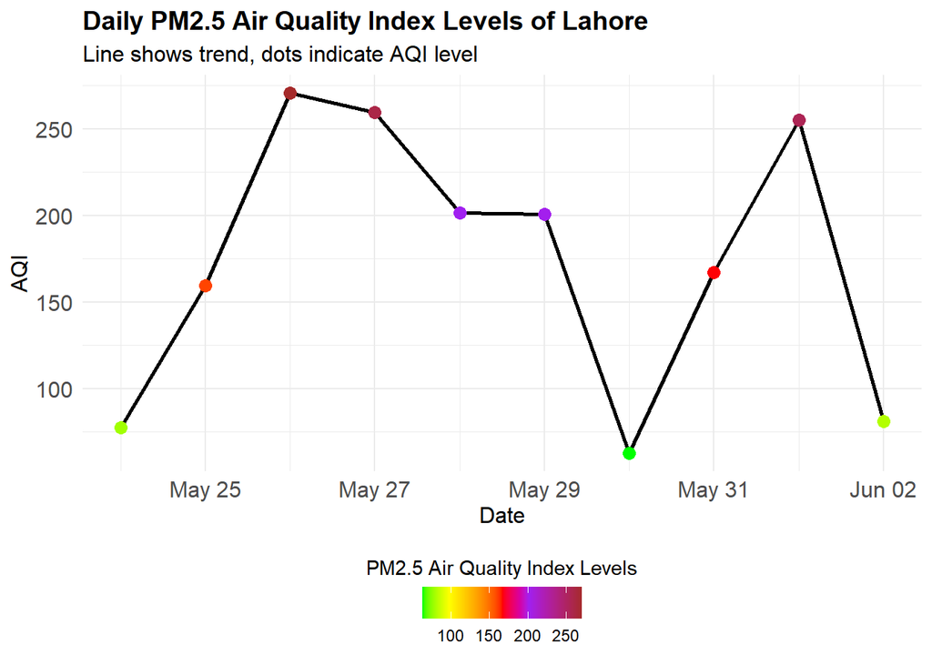

# **CHALLENGES**

The activities unfolded as planned, with some challenges encountered along the way. The main difficulties were:

- **Finding an appropriate API**: The initial challenge was to find an API that provided air quality data for the specific location of interest. Due to limitations, I had to choose a different location based on where the satellite data was available.
- **Ensuring accurate and timely data retrieval**: It was essential to ensure that the data fetched was both accurate and updated in real-time to provide reliable alerts.
- **Managing environment variables securely**: Storing and managing API keys and tokens securely was crucial to maintain the integrity and security of the system.
- **Ensuring reliable SMS delivery through Twilio**: Integrating and ensuring the reliability of SMS delivery through Twilio required careful configuration and testing.
- **Dealing with missing or incomplete data**: Handling scenarios where the API response was incomplete or missing data required robust error handling and fallback mechanisms.

# **LIMITATIONS AND CONSIDERATIONS**

- **Multi-language support**

Constraint: The project currently provides health advice only in English. Finding a free API supporting multiple languages like Punjabi and Urdu was not possible.

Consideration: Consider integrating paid APIs for language support or explore collaborations for funding.

- **Advanced notification system**

Constraint: The notification system is basic and not customizable based on user health conditions or preferences.

Consideration: Develop a system allowing users to customize alerts.

- **User feedback loop**

Constraint: There is no mechanism for collecting user feedback on alert effectiveness.

Consideration: Implement channels for user feedback to enhance the system.

- **Scalability**

Constraint: The project is focused on Lahore but could be expanded to other regions.

Consideration: Scale the project to cover more cities, adapting to local air quality standards.

- **Data privacy**

Constraint: Ensuring data privacy is crucial, especially with future expansions.

Consideration: Develop a data privacy framework for handling user data.

# **CONCLUSION**

Despite current constraints, this project demonstrates significant potential for improving public health awareness through real-time data. Implementing this alert system could enhance public health and potentially improve health outcomes in Lahore. While further study is needed, the system’s timely alerts and health advice show the power of technology in combating air pollution. With more resources and time, it can offer health advice in multiple languages, enhancing accessibility and effectiveness. By addressing constraints and incorporating improvements, the project can become a powerful tool for protecting public health across regions. Continued use and expansion can play a critical role in public health initiatives.

**Take action now! Stay informed and engage actively with Lahore’s air quality initiatives to help improve community health and environment.**

# **REFERENCES**

World Health Organization. (2021). Air pollution. Retrieved from https://www.who.int/health-topics/air-pollution

The Guardian. (2023, November). Pollution from fossil fuels contributes to approximately 5 million deaths annually. Retrieved from https://www.theguardian.com/environment/2023/nov/29/air-pollution-from-fossil-fuels-kills-5-million-people-a-year

IQAir. (2023). World’s most polluted cities. Retrieved from https://www.iqair.com/world-most-polluted-cities